**Vessel**

**Vessel Name Meaning**

Cathlamet

From the Kathlamet tribe, the Chinook word calamet meaning "stone," was given to the tribe because its members lived along a rocky stretch of the Columbia River. A city also bears its name.

Chelan

From the Chelan language: Tsill-ane, meaning "deep water." The tribe lived along Lake Chelan, which is very deep. A city, county and river also bear the name.

Chetzemoka

The name honors a friendly Native American Chief of the S'Klallam Tribe near the Port Townsend area who died in 1888.

Chimacum

“The Chimacum People who spoke the Chimaquan dialect, inhabited the area of the Quimper Peninsula, in Washington State, which includes Port Hadlock and Port Townsend. The modern area of Chimacum, Washington, is named after the Tribe.”

Issaquah

"Snake." Native Americans who traveled around the Issaquah region called it Sqwak because of the squawking sounds of the birds. The natives habitually said "ish" before words, forming the word "isquowh," which when spelled by settlers became Issaquah.

Kaleetan

[figure not shown]

Native American/Chinook: "arrow."

Kennewick

Kennewick –Sah-ap-tin, Plains dialect: “winter paradise; winter haven; grassy place; grassy slope”

Kitsap

A Suquamish tribal Chief in the 1800's. A county is also named after him.

Kittitas

Tribe of "shoal people" who lived along the shallow portion of the Yakima River near Ellensburg. A county and town are also named after the tribe.

Puyallup

From the Puyallup language: "generous people." The Puyallup tribe had a reputation for generosity in dealing with traders and travelers. Early settler Ezra Meeker renamed his town from Franklin in 1877 looking for something unique. Besides the tribe and town, Puyallup is also used on a river and a Mt. Rainier glacier.

Salish

Salish – From Salishan/ a group of people in the Northwestern United States and Lower Mainland Canada who speak a common language.

Samish

From the Samish Nation, "The Giving People"

Sealth

[figure not shown]

The Chief of the Duwamish and Suquamish tribes who befriended early settlers in the 1850-60's and signed the Point Elliot Treaty of 1855.

Spokane

[figure not shown]

Eastern Washington Native American tribe: "children of the sun or sun people." A city, county and river are also named after the tribe.

Suquamish

The Suquamish are known as the "people of the clear salt water" in the Southern Coast Salish Lushootseed language. Suquamish is also the name of the beach in front of where the "Old Man House" once stood on Agate Passage in Kitsap County.

Tacoma

From the native word Tah-ho-mah (now Mt. Rainier), meaning "snowy mountain." Tacoma was first attributed to the mountain in an 1860s book, "The Canoe and the Saddle" by Theodore Winthrop, a popular volume on the early Pacific Northwest. The city picked the name over Commencement City when the railroad made its terminius there in the 1870s.

Tillikum

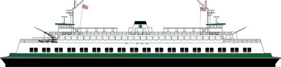

Chinook Jargon: "friends; relatives."

Tokitae

Tokitae means "nice day, pretty colors" in Chinook jargon.

Walla Walla

[figure not shown]

Nez Perce for "place of many waters." The Walla Walla are a Southeastern Washington tribe. A city, county, and river are also named after the tribe.

Wenatchee

From the Yakama language comes the word wenatchi for "river flowing from canyon." When Lewis and Clark traveled through the Columbia River valley in 1803-1805, they mentioned the word Wenatchee in their journal, hearing of the river and the tribe living along its banks. A city, lake, river, and national forest are also named after the tribe.

Yakima

[figure not shown]

From the Yakama language, "Yakima" has many meanings: "to become peopled; black bears; runaway; and/or people of the narrow river." A city, county and river are also named after the English spelling of the tribe, Yakima.